# Capital Bikeshare Dynamic Rebalancing Optimization

### 15.7 Station-Capacity Sensitivity

A one-dock increase is tested at selected stations. Initial bike inventory is held fixed so the experiment isolates physical dock capacity. The local dual estimate combines capacity-constraint marginals and inventory upper-bound marginals.

```python
capacity_constraint_categories = [
    "post_rebalancing_capacity",
    "arrival_dock_capacity",
]

capacity_rhs_shadow = (
    ub_dual_analysis.loc[
        ub_dual_analysis[
            "category"
        ]
        .isin(
            capacity_constraint_categories
        )
    ]
    .groupby(
        "short_name"
    )[
        "shadow_value"
    ]
    .sum()
)
```

```python
upper_bound_marginals = np.asarray(
    lp_result.upper.marginals,
    dtype=float,
)

capacity_dual_records = []

for station_id in (
    station_ids
):

    i = station_position[
        station_id
    ]

    upper_bound_value = 0.0

    for k in range(
        1,
        time_count + 1,
    ):

        variable_index = idx_s(
            k,
            i,
        )

        upper_bound_value += (
            -upper_bound_marginals[
                variable_index
            ]
        )

    rhs_value = float(
        capacity_rhs_shadow.get(
            station_id,
            0.0,
        )
    )

    rhs_value = max(
        0.0,
        rhs_value,
    )

    upper_bound_value = max(
        0.0,
        upper_bound_value,
    )

    capacity_dual_records.append(
        {
            "short_name":
                station_id,

            "station_name":
                station_name_lookup.get(
                    station_id,
                    station_id,
                ),

            "capacity_constraint_value":
                rhs_value,

            "inventory_upper_bound_value":
                upper_bound_value,

            "dual_estimated_value":
                (
                    rhs_value
                    +
                    upper_bound_value
                ),
        }
    )

capacity_dual_estimates = pd.DataFrame(
    capacity_dual_records
)
```

Select stations using both dual value and observed baseline dock pressure.

```python
baseline_capacity_pressure = (
    baseline_simulation
    .groupby(
        [
            "short_name",
            "station_name",
        ],
        as_index=False,
    )[
        "blocked_arrivals"
    ]
    .sum()
    .sort_values(
        "blocked_arrivals",
        ascending=False,
    )
)
```

```python
candidate_station_ids = []

for station_id in (
    capacity_dual_estimates.loc[
        capacity_dual_estimates[
            "dual_estimated_value"
        ]
        > dual_tolerance
    ]
    .nlargest(
        6,
        "dual_estimated_value",
    )[
        "short_name"
    ]
):

    if (
        station_id
        in station_position
        and
        station_id
        not in candidate_station_ids
    ):

        candidate_station_ids.append(
            station_id
        )

for station_id in (
    baseline_capacity_pressure[
        "short_name"
    ]
):

    if (
        station_id
        in station_position
        and
        station_id
        not in candidate_station_ids
    ):

        candidate_station_ids.append(
            station_id
        )

    if len(
        candidate_station_ids
    ) >= 6:

        break

if len(
    candidate_station_ids
) == 0:

    candidate_station_ids = (
        capacity_dual_estimates
        .nlargest(
            6,
            "dual_estimated_value",
        )[
            "short_name"
        ]
        .tolist()
    )
```

```python
capacity_sensitivity_rows = []

for station_id in (
    candidate_station_ids[
        :6
    ]
):

    result = solve_lp_variant(
        hourly_budget=
            current_hourly_budget,

        failure_penalty=
            service_failure_penalty,

        capacity_changes={
            station_id:
                1.0
        },
    )

    metrics = extract_lp_metrics(
        result,
        service_failure_penalty,
    )

    dual_row = (
        capacity_dual_estimates.loc[
            capacity_dual_estimates[
                "short_name"
            ]
            == station_id
        ]
        .iloc[0]
    )

    capacity_sensitivity_rows.append(
        {
            "short_name":
                station_id,

            "station_name":
                dual_row[
                    "station_name"
                ],

            "dual_estimated_objective_improvement":
                dual_row[
                    "dual_estimated_value"
                ],

            "finite_difference_objective_improvement":
                (
                    base_lp_metrics[
                        "objective_value"
                    ]
                    -
                    metrics.get(
                        "objective_value",
                        np.nan,
                    )
                ),

            "service_failure_reduction":
                (
                    base_lp_metrics[
                        "total_service_failures"
                    ]
                    -
                    metrics.get(
                        "total_service_failures",
                        np.nan,
                    )
                ),

            "relocation_bike_km_reduction":
                (
                    base_lp_metrics[
                        "relocation_bike_km"
                    ]
                    -
                    metrics.get(
                        "relocation_bike_km",
                        np.nan,
                    )
                ),

            "success":
                metrics[
                    "success"
                ],
        }
    )

capacity_sensitivity = (
    pd.DataFrame(
        capacity_sensitivity_rows
    )
    .sort_values(
        "finite_difference_objective_improvement",
        ascending=False,
    )
    .reset_index(
        drop=True
    )
)

capacity_sensitivity_display = (
    capacity_sensitivity[
        [
            "short_name",
            "station_name",
            "dual_estimated_objective_improvement",
            "finite_difference_objective_improvement",
            "service_failure_reduction",
            "relocation_bike_km_reduction",
            "success",
        ]
    ]
    .rename(
        columns={
            "short_name":
                "Station ID",

            "station_name":
                "Station",

            "dual_estimated_objective_improvement":
                "Dual estimate",

            "finite_difference_objective_improvement":
                "Finite difference",

            "service_failure_reduction":
                "Failure reduction",

            "relocation_bike_km_reduction":
                "Bike-km reduction",

            "success":
                "Solved",
        }
    )
)

(
    capacity_sensitivity_display
    .round(6)
    .style
    .hide(axis="index")
)
```

| Station ID | Station | Dual estimate | Finite difference | Failure reduction | Bike-km reduction | Solved |
| --- | --- | --- | --- | --- | --- | --- |
| 31116 | California St & Florida Ave NW | 0.320537 | 0.320537 | 0.000000 | 0.320537 | True |
| 31202 | 14th & R St NW | 0.263987 | 0.263987 | 0.000000 | 0.263987 | True |
| 31201 | 15th & P St NW | 0.227358 | 0.227358 | 0.000000 | 0.227358 | True |
| 31114 | 18th St & Wyoming Ave NW | 0.151805 | 0.151805 | 0.000000 | 0.151805 | True |
| 31275 | New Hampshire Ave & 24th St NW | 0.000000 | 0.000000 | 0.000000 | 0.000000 | True |
| 31533 | Tanner Park | 0.000000 | 0.000000 | 0.000000 | 0.000000 | True |

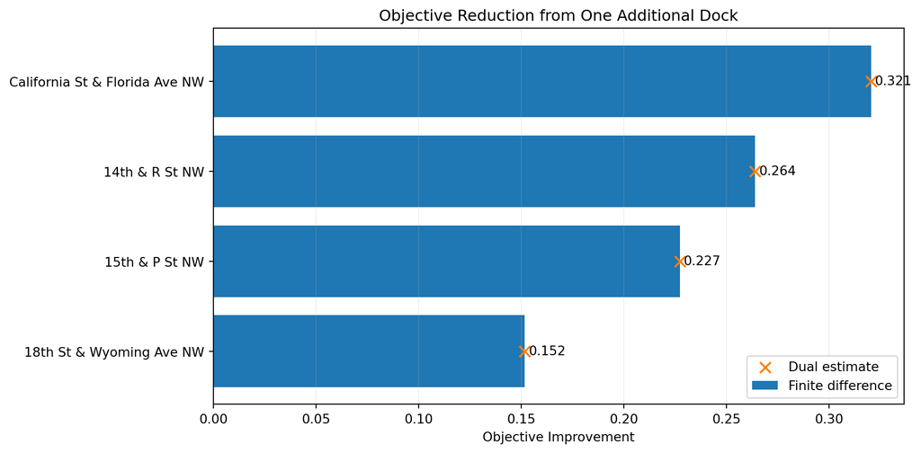

```python
capacity_plot_data = (
    capacity_sensitivity.loc[
        capacity_sensitivity[
            "success"
        ]
        &
        capacity_sensitivity[
            "finite_difference_objective_improvement"
        ]
        .notna()
        &
        (
            capacity_sensitivity[
                "finite_difference_objective_improvement"
            ]
            > dual_tolerance
        )
    ]
    .sort_values(
        "finite_difference_objective_improvement"
    )
    .copy()
)

if len(
    capacity_plot_data
) > 0:

    fig, ax = plt.subplots(
        figsize=(
            10,
            5,
        )
    )

    capacity_bars = ax.barh(
        capacity_plot_data[
            "station_name"
        ],
        capacity_plot_data[
            "finite_difference_objective_improvement"
        ],
        label="Finite difference",
    )

    ax.scatter(
        capacity_plot_data[
            "dual_estimated_objective_improvement"
        ],
        capacity_plot_data[
            "station_name"
        ],
        marker="x",
        s=70,
        label="Dual estimate",
        zorder=3,
    )

    ax.bar_label(
        capacity_bars,
        fmt="%.3f",
        padding=3,
    )

    ax.set_title(
        "Objective Reduction from One Additional Dock"
    )

    ax.set_xlabel(
        "Objective Improvement"
    )

    ax.set_ylabel(
        ""
    )

    ax.set_xlim(
        left=0
    )

    ax.legend()

    ax.grid(
        axis="x",
        alpha=0.20,
    )

    plt.tight_layout()
    plt.show()

else:

    print(
        "No tested one-dock increase has a positive objective value."
    )
```

### 15.8 Sensitivity Findings

```python
valid_capacity_rows = (
    capacity_sensitivity.loc[
        capacity_sensitivity[
            "success"
        ]
        &
        capacity_sensitivity[
            "finite_difference_objective_improvement"
        ]
        .notna()
    ]
    .copy()
)

if len(
    valid_capacity_rows
) > 0:

    best_capacity_row = (
        valid_capacity_rows
        .sort_values(
            "finite_difference_objective_improvement",
            ascending=False,
        )
        .iloc[0]
    )

    best_capacity_station = (
        best_capacity_row[
            "station_name"
        ]
    )

    best_capacity_value = float(
        best_capacity_row[
            "finite_difference_objective_improvement"
        ]
    )

else:

    best_capacity_station = (
        "Not available"
    )

    best_capacity_value = np.nan

current_budget_binding_intervals = int(
    budget_shadow_prices[
        "binding"
    ]
    .sum()
)

current_budget_shadow_value = float(
    budget_shadow_prices[
        "shadow_value"
    ]
    .sum()
)
```

```python
sensitivity_findings = pd.DataFrame(
    {
        "Measure": [
            "Current hourly rebalancing budget",
            "Lowest tested budget with zero service failures",
            "Lowest tested budget reproducing current objective",
            "Current service-failure penalty",
            "Lowest tested penalty with zero service failures",
            "Current binding hourly-budget intervals",
            "Current aggregate budget shadow value",
            "Highest-value station for one additional dock",
            "Objective reduction from one additional dock",
        ],

        "Value": [
            current_hourly_budget,
            minimum_zero_failure_budget,
            minimum_objective_matching_budget,
            service_failure_penalty,
            minimum_zero_failure_penalty,
            current_budget_binding_intervals,
            current_budget_shadow_value,
            best_capacity_station,
            best_capacity_value,
        ],
    }
)

(
    sensitivity_findings
    .style
    .hide(axis="index")
)
```

| Measure | Value |
| --- | --- |
| Current hourly rebalancing budget | 76.000000 |
| Lowest tested budget with zero service failures | 8.000000 |
| Lowest tested budget reproducing current objective | 10.000000 |
| Current service-failure penalty | 25.000000 |
| Lowest tested penalty with zero service failures | 0.700000 |
| Current binding hourly-budget intervals | 0 |
| Current aggregate budget shadow value | 0.000000 |
| Highest-value station for one additional dock | California St & Florida Ave NW |
| Objective reduction from one additional dock | 0.320537 |

```python
from IPython.display import Markdown, display


def format_tested_value(
    value,
):

    if pd.isna(
        value
    ):

        return (
            "not identified"
        )

    return f"{float(value):g}"


budget_status_text = (
    "nonbinding"
    if current_budget_binding_intervals == 0
    else
    (
        "binding in "
        f"{current_budget_binding_intervals} interval(s)"
    )
)

capacity_result_text = (
    (
        "The highest tested one-dock value occurs at "
        f"**{best_capacity_station}**, with an objective "
        f"reduction of **{best_capacity_value:.3f}**."
    )
    if np.isfinite(
        best_capacity_value
    )
    else
    "No positive one-dock value was identified in the tested stations."
)

summary_markdown = f"""
The current hourly rebalancing budget of **{current_hourly_budget:g}** is
**{budget_status_text}**, with an aggregate shadow value of
**{current_budget_shadow_value:.3f}**. Among the tested alternatives, a budget
of **{format_tested_value(minimum_zero_failure_budget)}** bikes per hour is the
lowest value that eliminates all service failures, while a budget of
**{format_tested_value(minimum_objective_matching_budget)}** is the lowest
value that reproduces the current optimal objective.

A service-failure penalty of
**{format_tested_value(minimum_zero_failure_penalty)}** is the lowest tested
value that preserves zero failures. Because the base optimized solution already
has zero service failures, the tested one-dock additions primarily reduce
relocation effort rather than improve the station-event success rate.
{capacity_result_text}
"""

display(
    Markdown(
        summary_markdown
    )
)
```

The current hourly rebalancing budget of **76** is **nonbinding**, with an aggregate shadow value of **0.000**. Among the tested alternatives, a budget of **8** bikes per hour is the lowest value that eliminates all service failures, while a budget of **10** is the lowest value that reproduces the current optimal objective.

A service-failure penalty of **0.7** is the lowest tested value that preserves zero failures. Because the base optimized solution already has zero service failures, the tested one-dock additions primarily reduce relocation effort rather than improve the station-event success rate. The highest tested one-dock value occurs at **California St & Florida Ave NW**, with an objective reduction of **0.321**.

The reported shadow prices are local values around the current LP solution. The broader budget, penalty, and capacity experiments re-solve the model and therefore capture changes that may move the solution to a different optimal basis.

### 15.9 Save the Dual and Sensitivity Outputs

```python
constraint_dual_summary.to_csv(
    processed_dir
    / "constraint_dual_summary.csv",
    index=False,
)

ub_dual_analysis.to_csv(
    processed_dir
    / "lp_inequality_dual_analysis.csv",
    index=False,
)

budget_shadow_prices.to_csv(
    processed_dir
    / "rebalancing_budget_shadow_prices.csv",
    index=False,
)

top_shadow_constraints.to_csv(
    processed_dir
    / "top_shadow_constraints.csv",
    index=False,
)

budget_sensitivity.to_csv(
    processed_dir
    / "rebalancing_budget_sensitivity.csv",
    index=False,
)

budget_dual_validation.to_csv(
    processed_dir
    / "rebalancing_budget_dual_validation.csv",
    index=False,
)

penalty_sensitivity.to_csv(
    processed_dir
    / "service_penalty_sensitivity.csv",
    index=False,
)

capacity_dual_estimates.to_csv(
    processed_dir
    / "station_capacity_dual_estimates.csv",
    index=False,
)

capacity_sensitivity.to_csv(
    processed_dir
    / "station_capacity_sensitivity.csv",
    index=False,
)

sensitivity_findings.to_csv(
    processed_dir
    / "optimization_sensitivity_findings.csv",
    index=False,
)
```

```python
print(
    "Current hourly budget:",
    current_hourly_budget
)

print(
    "Lowest tested budget with zero service failures:",
    minimum_zero_failure_budget
)

print(
    "Lowest tested budget reproducing current objective:",
    minimum_objective_matching_budget
)

print(
    "Current service penalty:",
    service_failure_penalty
)

print(
    "Lowest tested penalty with zero service failures:",
    minimum_zero_failure_penalty
)

print(
    "Current aggregate budget shadow value:",
    round(
        current_budget_shadow_value,
        6,
    )
)
```

```
Current hourly budget: 76.0
Lowest tested budget with zero service failures: 8.0
Lowest tested budget reproducing current objective: 10.0
Current service penalty: 25.0
Lowest tested penalty with zero service failures: 0.7
Current aggregate budget shadow value: 0.0
```

**Interactive Decision Support**

## Part 16 — Standalone Interactive Decision-Support Application

> **Interactive Version:** Open the Capital Bikeshare Rebalancing Dashboard

The standalone application converts the simulation and optimization outputs from Parts 13–15 into an interactive decision-support interface. It is separated from the analytical report so that model development and operational exploration remain distinct.

### 16.1 Decision-Support Scope

The application allows the user to explore the modeled rebalancing scenario without reading or rerunning the optimization code.

The main controls include:

- selection of one or more Washington, DC ZIP codes;
- comparison of no rebalancing, the reactive heuristic, and LP optimization;
- selection of the modeled hourly interval;
- comparison of inventory before rebalancing, after rebalancing, and at the end of each interval;
- exploration of precomputed LP rebalancing-budget scenarios.

The displayed outputs include station inventory conditions, service failures, optimized bike transfers, relocation effort, and station-event service performance.

### 16.2 Data Flow

The interactive application uses processed outputs generated by the analytical workflow rather than recomputing the full model in the browser.

The workflow is:

```
Historical trip flows
        ↓
Dynamic inventory simulation
        ↓
Linear rebalancing optimization
        ↓
Precomputed scenario outputs
        ↓
Standalone interactive application
```

The application therefore acts as the presentation and decision-support layer of the project, while the QMD report remains the reproducible modeling and analysis layer.

### 16.3 Interactive Scenario Design

Station-level simulation outputs are linked to station coordinates and DC ZIP-code polygons. User selections filter the corresponding stations, service metrics, and transfer corridors.

For LP scenarios, alternative hourly rebalancing budgets are solved during the analytical workflow and stored as precomputed results. The interactive application uses these solutions rather than re-solving the full optimization model during user interaction.

This design keeps the standalone application lightweight while preserving direct consistency with the optimization results reported in Parts 14 and 15.

### 16.4 Main Decision Outputs

The application summarizes each selected scenario using:

- selected station count;
- requested station events;
- unmet departures and blocked arrivals;
- total service failures;
- station-event success rate;
- bikes rebalanced;
- relocation bike-km;
- station-level inventory status;
- optimized transfer corridors.

ZIP-code selection, policy selection, time selection, and LP budget selection update the displayed results together.

**Conclusions**

## Part 17 — Practical Findings, Limitations, and Next Steps

This project developed an applied decision-support framework for Capital Bikeshare by combining historical trip-flow processing, geospatial analysis, dynamic inventory simulation, linear optimization, sensitivity analysis, and interactive visualization.

The framework converts individual trip records into station-level hourly flows, simulates inventory conditions under explicit initial assumptions, and identifies targeted bike transfers that improve modeled service while controlling relocation effort.

### 17.1 Practical Findings

The three modeled policies produced substantially different service and relocation outcomes.

| Policy | Unmet departures | Blocked arrivals | Total service failures | Station-event success rate | Bikes rebalanced | Relocation bike-km |
| --- | --- | --- | --- | --- | --- | --- |
| No rebalancing | 17 | 10 | 27 | 99.235% | 0 | 0.000 |
| Reactive heuristic | 5 | 0 | 5 | 99.858% | 84 | 209.974 |
| LP optimization | 0 | 0 | 0 | 100.000% | 27 | 5.657 |

Without rebalancing, the selected scenario produced 17 unmet departures and 10 blocked arrivals. These failures were concentrated at a small number of station-time combinations rather than distributed evenly across the modeled network.

The reactive heuristic substantially improved service, reducing total failures from 27 to 5 and eliminating blocked arrivals. However, it required 84 bike movements and approximately 209.974 relocation bike-km. The heuristic therefore demonstrated that simple threshold-based intervention can improve station availability, but it did not coordinate transfers efficiently across the entire network.

The LP solution eliminated all modeled service failures while moving only 27 bikes over approximately 5.657 bike-km. Compared with the heuristic, the optimized policy moved 57 fewer bikes and reduced relocation bike-km by approximately 97%. The main benefit of optimization was therefore not merely additional rebalancing, but better spatial and temporal coordination of the same limited resource.

### 17.2 Resource and Sensitivity Findings

The current modeled hourly rebalancing budget of 76 bikes was nonbinding and had an aggregate shadow value of zero. This indicates that the current solution was not limited by the system-wide hourly resource allowance.

Among the tested budget values:

- 8 bikes per hour was the lowest tested budget that eliminated all service failures;
- 10 bikes per hour was the lowest tested budget that reproduced the current optimal objective;
- additional budget above this level did not improve the modeled solution.

These values are thresholds within the tested sensitivity grid rather than exact analytical breakpoints. Nevertheless, they show that the original budget of 76 bikes per hour was substantially larger than required for the selected scenario.

The service-failure penalty produced a similar result. A penalty of 0.7 was the lowest tested value that maintained zero service failures, while the primary model used a penalty of 25. The selected objective therefore strongly prioritized customer service relative to relocation distance.

The dual analysis further showed that the most important constraints were local departure-inventory constraints at particular stations and intervals. Fourteen departure-inventory constraints were binding, and seven had positive shadow values. By contrast, the hourly rebalancing-budget constraints had no positive shadow value at the current solution.

Additional dock capacity did not further increase the station-event success rate because the optimized solution already achieved zero failures. Its value instead appeared through reduced relocation effort. Among the tested stations, California St & Florida Ave NW had the highest value for one additional dock, with an estimated objective reduction of approximately 0.321.

### 17.3 Operational Interpretation

The results suggest that bike-sharing imbalance is primarily a local and time-dependent coordination problem. A system may have enough bikes and docks overall while still experiencing shortages or blocked arrivals at individual stations.

A reactive policy can respond to visible shortages, but local threshold rules do not account for the full network, future demand within the modeled horizon, or the cost of alternative transfer corridors. This can lead to unnecessary or excessively long movements.

The LP model instead evaluates station inventories, expected arrivals and departures, capacities, transfer distances, and rebalancing limits together. It directs bikes only to the station-time combinations where additional inventory has the greatest modeled value.

The optimized transfer map and shadow-price results should therefore be interpreted together. The transfer map shows the recommended physical movements, while the dual analysis identifies the local constraints responsible for those movements.

The standalone interactive application will extend this interpretation by allowing users to select ZIP codes, time intervals, policies, inventory states, and precomputed budget scenarios. Its purpose is to make the analytical results easier to inspect rather than to replace the underlying reproducible model.

### 17.4 Limitations

The results are scenario-based planning outputs rather than a reconstruction of actual Capital Bikeshare operations.

First, historical January 2025 station inventories were not available. The simulation therefore initialized each station at 50% of reference capacity. Although alternative initial fill ratios were tested, inventory conditions remain an important source of model sensitivity.

Second, the historical trip records and the reference GBFS station data do not represent the same moment in time. Current station capacities are used as structural proxies, while current bike availability is not treated as the historical January 2025 inventory. Changes to station locations or capacities between the historical trip period and the current GBFS snapshot may therefore affect the simulated results.

Third, the trip dataset records completed rides. It does not directly observe customers who abandoned a trip because no bike or dock was available. The reported service failures are therefore simulated shortages and capacity conflicts under the model assumptions, not observed historical customer failures. Observed trip counts may also understate latent demand at stations that were already empty or full.

A related data-coverage limitation is that only 69.16% of departure events and 68.08% of arrival events contain identifiable station IDs. Among events with station IDs, approximately 98% match the reference network, but events without usable station identifiers cannot be assigned to the station-level model. The results therefore characterize identifiable station-based activity rather than all Capital Bikeshare trip activity.

More fundamentally, the current framework is station-centric rather than activity-aware. Historical trip records indirectly reflect human movement, but the model treats station departures and arrivals as external demand inputs. It optimizes station inventories, simulated service outcomes, and bike-transfer decisions after the station-level demand pattern has already been specified.

The model does not explicitly identify why people are traveling or predict demand from the activities that generate those trips. For example, it does not distinguish among commuting, school schedules, tourism, shopping, recreation, concerts, sporting events, or disruptions to public transportation. It can determine how bikes should be redistributed for a given station-flow scenario, but it cannot independently anticipate how changes in human activity will shift demand across locations and time periods.

This limits the model’s ability to make fully proactive recommendations under new or changing conditions. A station may require additional bikes because a nearby workplace is closing, a class period is ending, a transit disruption has occurred, or a major event is about to begin. These behavioral and activity-based signals are not represented in the current optimization.

Fourth, the initial optimization covers 377 Washington, DC stations and a selected three-hour operating window. The results do not yet represent the entire Capital Bikeshare regional network, other times of day, seasonal patterns, special events, or long-term operating conditions. The selected period is useful for comparing policies under a controlled scenario, but it is not sufficient for evaluating system-wide performance over an entire day or year.

Fifth, the model uses deterministic observed flows for the selected scenario. It does not represent forecast error or uncertainty in future departures and arrivals. A transfer plan that is optimal for one realized demand pattern may perform differently if actual demand changes unexpectedly.

The primary simulation and optimization also use one-hour intervals, with rebalancing applied before passenger departures and arrivals within each interval. The time-step sensitivity analysis produced 27 baseline service failures at the 60-minute resolution, compared with 20 failures at both the 15-minute and 5-minute resolutions. This indicates that within-hour event timing can materially affect the simulated outcomes. A finer-resolution optimization may therefore produce different service and transfer decisions.

The LP is solved over a reduced candidate transfer network rather than every possible station pair. Each station is connected to its 12 nearest stations, producing 5,402 directed candidate arcs. This restriction controls model size and emphasizes local transfers, but the reported solution is optimal only within the allowed candidate network. Permitting all station pairs, multi-stop transfers, or alternative network designs could change the recommended solution.

Sixth, straight-line geographic distance is used as the relocation-cost proxy. Actual vehicle travel would depend on the road network, traffic, loading time, parking access, one-way streets, station accessibility, and other operational routing constraints. Relocation bike-km should therefore be interpreted as a comparative distance measure rather than an estimate of actual truck travel.

Finally, the LP uses continuous transfer variables and does not explicitly model individual trucks, depots, vehicle capacities, driver shifts, loading times, route sequencing, or integer bike movements. It should therefore be interpreted as a station-level planning benchmark rather than a complete vehicle-dispatch plan.

### 17.5 Next Steps

The most important next step is to extend the current station-level framework into an activity-aware demand-planning system. The present model successfully optimizes station inventories, simulated service outcomes, and bike-transfer decisions after station-level departures and arrivals have already been supplied. However, it does not explicitly model the human activities that generate those trips.

Station demand could instead be forecast using information about commuting patterns, employment and residential density, school schedules, land use, tourism, major events, weather, public-transit conditions, holidays, and time-of-day travel behavior. These variables could help explain why demand shifts across locations and when those shifts are likely to occur.

Activity-aware forecasts could estimate where and when people are likely to request or return bikes before the resulting station imbalance occurs. The predicted demand could then be passed into a rolling-horizon or stochastic optimization model, allowing bikes to be repositioned proactively rather than only reacting to a preselected station-flow scenario.

Such an extension would connect human mobility behavior to operational rebalancing decisions:

```
Human activities and mobility conditions
        ↓
Spatiotemporal demand forecasting
        ↓
Predicted station departures and arrivals
        ↓
Dynamic inventory simulation
        ↓
Rolling-horizon rebalancing optimization
```

Historical or archived GBFS inventory data would provide another major improvement. Observed station inventories would allow the simulation to begin from actual system conditions rather than an assumed initial fill ratio. Repeated inventory snapshots could also support model validation by comparing simulated station trajectories with observed changes over time.

A rolling-horizon implementation could repeatedly update station inventories, demand forecasts, and transfer decisions throughout the day. Instead of solving a single deterministic three-hour scenario, the model could re-optimize whenever new trip, inventory, weather, transit, or event information becomes available.

A mixed-integer vehicle-routing extension could represent whole-bike transfers, truck capacities, depots, driver shifts, loading times, route sequencing, road-network travel times, and access constraints. This would convert the current station-level planning benchmark into a more directly implementable dispatch model.

The analysis could also be expanded beyond the 377 modeled Washington, DC stations to the full Capital Bikeshare service region. Testing the framework across multiple days, seasons, demand levels, and initial inventory conditions would show whether the reported improvements remain stable under different operating environments. Stochastic or robust optimization could further protect rebalancing plans against demand-forecast uncertainty.

Finally, the separate interactive application can be deployed through GitHub Pages and linked from Part 16. The application will provide a concise operational interface for exploring locations, policies, time intervals, inventory states, and precomputed optimization scenarios, while the main QMD report remains the complete reproducible analytical workflow.

The central result of the project is that effective rebalancing depends more on coordinated allocation than on relocation volume alone. In the selected scenario, the optimized policy achieved complete modeled station-event service with substantially less movement than the reactive heuristic. However, the current framework remains primarily station-centric: it optimizes the consequences of a given station-flow pattern without explicitly predicting the human activities that create that pattern. Integrating activity-aware demand forecasting with dynamic optimization is therefore the most important direction for future development.